# Risk Factor Analysis

## Outcome Variable

**Outcome Variable:** whz

## Predictor Variables

**Intervention Variable:** predfeed36

**Adjustment Set:**

- arm
- sex
- month
- brthmon
- W_mage
- meducyrs
- feducyrs
- hhwealth_quart
- hfoodsec
- W_mhtcm
- W_mwtkg
- W_mbmi
- vagbrth
- W_gagebrth
- W_birthwt
- W_birthlen
- W_nrooms
- W_nchldlt5
- W_parity
- impfloor
- impsan
- safeh20
- delta_W_mage
- delta_meducyrs
- delta_feducyrs
- delta_hhwealth_quart
- delta_hfoodsec
- delta_W_mhtcm
- delta_W_mwtkg
- delta_W_mbmi
- delta_vagbrth
- delta_W_gagebrth
- delta_W_birthwt
- delta_W_birthlen
- delta_W_nrooms
- delta_W_nchldlt5
- delta_W_parity
- delta_impfloor
- delta_impsan
- delta_safeh20

## Stratifying Variables

The analysis was stratified on these variable(s):

- agecat
- studyid
- country

## Data Summary

| agecat | studyid | country | predfeed36 | n_cell | n |
| --- | --- | --- | --- | --- | --- |
| Birth | EE | PAKISTAN | 1 | 2 | 6 |
| Birth | EE | PAKISTAN | 0 | 4 | 6 |
| Birth | GMS-Nepal | NEPAL | 1 | 396 | 491 |
| Birth | GMS-Nepal | NEPAL | 0 | 95 | 491 |
| Birth | JiVitA-3 | BANGLADESH | 1 | 6746 | 8619 |
| Birth | JiVitA-3 | BANGLADESH | 0 | 1873 | 8619 |
| Birth | JiVitA-4 | BANGLADESH | 1 | 1714 | 2128 |
| Birth | JiVitA-4 | BANGLADESH | 0 | 414 | 2128 |
| Birth | MAL-ED | BANGLADESH | 1 | 69 | 208 |
| Birth | MAL-ED | BANGLADESH | 0 | 139 | 208 |
| Birth | MAL-ED | BRAZIL | 1 | 7 | 62 |
| Birth | MAL-ED | BRAZIL | 0 | 55 | 62 |
| Birth | MAL-ED | INDIA | 1 | 4 | 40 |
| Birth | MAL-ED | INDIA | 0 | 36 | 40 |
| Birth | MAL-ED | NEPAL | 1 | 1 | 25 |
| Birth | MAL-ED | NEPAL | 0 | 24 | 25 |
| Birth | MAL-ED | PERU | 1 | 57 | 218 |
| Birth | MAL-ED | PERU | 0 | 161 | 218 |
| Birth | MAL-ED | SOUTH AFRICA | 1 | 2 | 104 |
| Birth | MAL-ED | SOUTH AFRICA | 0 | 102 | 104 |
| Birth | MAL-ED | TANZANIA, UNITED REPUBLIC OF | 1 | 0 | 111 |
| Birth | MAL-ED | TANZANIA, UNITED REPUBLIC OF | 0 | 111 | 111 |
| 6 months | EE | PAKISTAN | 1 | 4 | 9 |
| 6 months | EE | PAKISTAN | 0 | 5 | 9 |
| 6 months | GMS-Nepal | NEPAL | 1 | 422 | 527 |
| 6 months | GMS-Nepal | NEPAL | 0 | 105 | 527 |
| 6 months | JiVitA-3 | BANGLADESH | 1 | 6576 | 8535 |
| 6 months | JiVitA-3 | BANGLADESH | 0 | 1959 | 8535 |
| 6 months | JiVitA-4 | BANGLADESH | 1 | 3252 | 4188 |
| 6 months | JiVitA-4 | BANGLADESH | 0 | 936 | 4188 |
| 6 months | LCNI-5 | MALAWI | 1 | 47 | 272 |
| 6 months | LCNI-5 | MALAWI | 0 | 225 | 272 |
| 6 months | MAL-ED | BANGLADESH | 1 | 81 | 240 |
| 6 months | MAL-ED | BANGLADESH | 0 | 159 | 240 |
| 6 months | MAL-ED | BRAZIL | 1 | 25 | 209 |
| 6 months | MAL-ED | BRAZIL | 0 | 184 | 209 |
| 6 months | MAL-ED | INDIA | 1 | 17 | 233 |
| 6 months | MAL-ED | INDIA | 0 | 216 | 233 |
| 6 months | MAL-ED | NEPAL | 1 | 8 | 235 |
| 6 months | MAL-ED | NEPAL | 0 | 227 | 235 |
| 6 months | MAL-ED | PERU | 1 | 72 | 272 |
| 6 months | MAL-ED | PERU | 0 | 200 | 272 |
| 6 months | MAL-ED | SOUTH AFRICA | 1 | 3 | 250 |
| 6 months | MAL-ED | SOUTH AFRICA | 0 | 247 | 250 |
| 6 months | MAL-ED | TANZANIA, UNITED REPUBLIC OF | 1 | 5 | 243 |
| 6 months | MAL-ED | TANZANIA, UNITED REPUBLIC OF | 0 | 238 | 243 |
| 6 months | SAS-FoodSuppl | INDIA | 1 | 0 | 168 |
| 6 months | SAS-FoodSuppl | INDIA | 0 | 168 | 168 |
| 24 months | EE | PAKISTAN | 1 | 0 | 3 |
| 24 months | EE | PAKISTAN | 0 | 3 | 3 |
| 24 months | GMS-Nepal | NEPAL | 1 | 362 | 445 |
| 24 months | GMS-Nepal | NEPAL | 0 | 83 | 445 |
| 24 months | JiVitA-3 | BANGLADESH | 1 | 3320 | 4317 |
| 24 months | JiVitA-3 | BANGLADESH | 0 | 997 | 4317 |
| 24 months | JiVitA-4 | BANGLADESH | 1 | 3144 | 4035 |
| 24 months | JiVitA-4 | BANGLADESH | 0 | 891 | 4035 |
| 24 months | LCNI-5 | MALAWI | 1 | 34 | 184 |
| 24 months | LCNI-5 | MALAWI | 0 | 150 | 184 |
| 24 months | MAL-ED | BANGLADESH | 1 | 69 | 212 |
| 24 months | MAL-ED | BANGLADESH | 0 | 143 | 212 |
| 24 months | MAL-ED | BRAZIL | 1 | 20 | 169 |
| 24 months | MAL-ED | BRAZIL | 0 | 149 | 169 |
| 24 months | MAL-ED | INDIA | 1 | 17 | 224 |
| 24 months | MAL-ED | INDIA | 0 | 207 | 224 |
| 24 months | MAL-ED | NEPAL | 1 | 8 | 227 |
| 24 months | MAL-ED | NEPAL | 0 | 219 | 227 |
| 24 months | MAL-ED | PERU | 1 | 53 | 201 |
| 24 months | MAL-ED | PERU | 0 | 148 | 201 |
| 24 months | MAL-ED | SOUTH AFRICA | 1 | 3 | 235 |
| 24 months | MAL-ED | SOUTH AFRICA | 0 | 232 | 235 |
| 24 months | MAL-ED | TANZANIA, UNITED REPUBLIC OF | 1 | 4 | 213 |
| 24 months | MAL-ED | TANZANIA, UNITED REPUBLIC OF | 0 | 209 | 213 |

The following strata were considered:

- agecat: 24 months, studyid: EE, country: PAKISTAN
- agecat: 24 months, studyid: GMS-Nepal, country: NEPAL
- agecat: 24 months, studyid: JiVitA-3, country: BANGLADESH
- agecat: 24 months, studyid: JiVitA-4, country: BANGLADESH
- agecat: 24 months, studyid: LCNI-5, country: MALAWI
- agecat: 24 months, studyid: MAL-ED, country: BANGLADESH
- agecat: 24 months, studyid: MAL-ED, country: BRAZIL
- agecat: 24 months, studyid: MAL-ED, country: INDIA
- agecat: 24 months, studyid: MAL-ED, country: NEPAL
- agecat: 24 months, studyid: MAL-ED, country: PERU
- agecat: 24 months, studyid: MAL-ED, country: SOUTH AFRICA
- agecat: 24 months, studyid: MAL-ED, country: TANZANIA, UNITED REPUBLIC OF
- agecat: 6 months, studyid: EE, country: PAKISTAN
- agecat: 6 months, studyid: GMS-Nepal, country: NEPAL
- agecat: 6 months, studyid: JiVitA-3, country: BANGLADESH
- agecat: 6 months, studyid: JiVitA-4, country: BANGLADESH
- agecat: 6 months, studyid: LCNI-5, country: MALAWI
- agecat: 6 months, studyid: MAL-ED, country: BANGLADESH
- agecat: 6 months, studyid: MAL-ED, country: BRAZIL
- agecat: 6 months, studyid: MAL-ED, country: INDIA
- agecat: 6 months, studyid: MAL-ED, country: NEPAL
- agecat: 6 months, studyid: MAL-ED, country: PERU
- agecat: 6 months, studyid: MAL-ED, country: SOUTH AFRICA
- agecat: 6 months, studyid: MAL-ED, country: TANZANIA, UNITED REPUBLIC OF
- agecat: 6 months, studyid: SAS-FoodSuppl, country: INDIA
- agecat: Birth, studyid: EE, country: PAKISTAN
- agecat: Birth, studyid: GMS-Nepal, country: NEPAL
- agecat: Birth, studyid: JiVitA-3, country: BANGLADESH
- agecat: Birth, studyid: JiVitA-4, country: BANGLADESH
- agecat: Birth, studyid: MAL-ED, country: BANGLADESH
- agecat: Birth, studyid: MAL-ED, country: BRAZIL
- agecat: Birth, studyid: MAL-ED, country: INDIA
- agecat: Birth, studyid: MAL-ED, country: NEPAL
- agecat: Birth, studyid: MAL-ED, country: PERU
- agecat: Birth, studyid: MAL-ED, country: SOUTH AFRICA
- agecat: Birth, studyid: MAL-ED, country: TANZANIA, UNITED REPUBLIC OF

### Dropped Strata

Some strata were dropped due to rare outcomes:

- agecat: Birth, studyid: EE, country: PAKISTAN
- agecat: Birth, studyid: MAL-ED, country: INDIA
- agecat: Birth, studyid: MAL-ED, country: NEPAL
- agecat: Birth, studyid: MAL-ED, country: SOUTH AFRICA
- agecat: Birth, studyid: MAL-ED, country: TANZANIA, UNITED REPUBLIC OF
- agecat: 6 months, studyid: EE, country: PAKISTAN
- agecat: 6 months, studyid: MAL-ED, country: SOUTH AFRICA
- agecat: 6 months, studyid: SAS-FoodSuppl, country: INDIA
- agecat: 24 months, studyid: EE, country: PAKISTAN
- agecat: 24 months, studyid: MAL-ED, country: SOUTH AFRICA
- agecat: 24 months, studyid: MAL-ED, country: TANZANIA, UNITED REPUBLIC OF

## Methods Detail

We’re interested in the causal parameters $E[Y_a]$ for all values of $a \in \mathcal{A}$. These parameters represent the mean outcome if, possibly contrary to fact, we intervened to set all units to have $A=a$. Under the randomization and positivity assumptions, these are identified by the statistical parameters $\psi_a=E_W[E_{Y|A,W}(Y|A=a,W)]$. In addition, we’re interested in the mean of $Y$, $E[Y]$ under no intervention (the observed mean). We will estimate these parameters by using SuperLearner to fit the relevant likelihood factors – $E_{Y|A,W}(Y|A=a,W)$ and $p(A=a|W)$, and then updating our likelihood fit using a joint TMLE.

For unadjusted analyses ($W=\{\}$), initial likelihoods were estimated using Lrnr_glm to estimate the simple $E(Y|A)$ and Lrnr_mean to estimate $p(A)$. For adjusted analyses, a small library containing Lrnr_glmnet, Lrnr_xgboost, and Lrnr_mean was used.

Having estimated these parameters, we will then use the delta method to estimate relative risks and attributable risks relative to a prespecified baseline level of $A$.

# Results Detail

## Results Plots

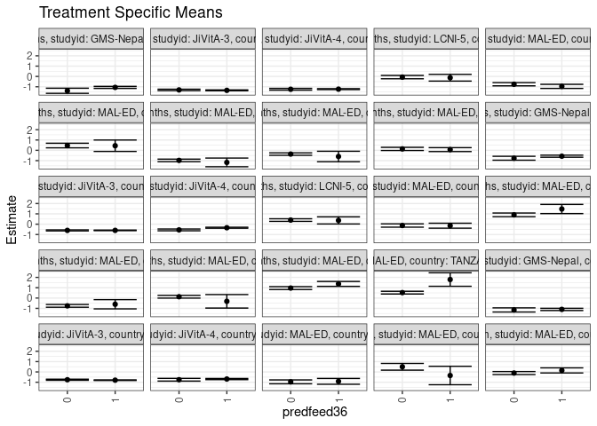

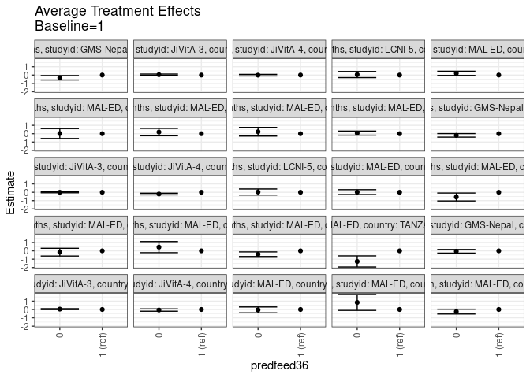

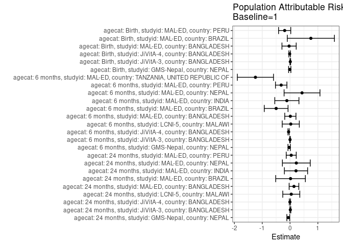

## Results Table

### Parameter: TSM

| agecat | studyid | country | intervention_level | baseline_level | estimate | ci_lower | ci_upper |
| --- | --- | --- | --- | --- | --- | --- | --- |
| Birth | GMS-Nepal | NEPAL | 1 | NA | -1.0982164 | -1.2065599 | -0.9898730 |
| Birth | GMS-Nepal | NEPAL | 0 | NA | -1.1513143 | -1.3526218 | -0.9500069 |
| Birth | JiVitA-3 | BANGLADESH | 1 | NA | -0.7981339 | -0.8250999 | -0.7711680 |
| Birth | JiVitA-3 | BANGLADESH | 0 | NA | -0.7568776 | -0.8092877 | -0.7044675 |
| Birth | JiVitA-4 | BANGLADESH | 1 | NA | -0.6884460 | -0.7445914 | -0.6323006 |
| Birth | JiVitA-4 | BANGLADESH | 0 | NA | -0.7565125 | -0.8894754 | -0.6235496 |
| Birth | MAL-ED | BANGLADESH | 1 | NA | -0.9136810 | -1.1966492 | -0.6307128 |
| Birth | MAL-ED | BANGLADESH | 0 | NA | -0.9613823 | -1.1490350 | -0.7737295 |
| Birth | MAL-ED | BRAZIL | 1 | NA | -0.3457143 | -1.2397629 | 0.5483343 |
| Birth | MAL-ED | BRAZIL | 0 | NA | 0.4981818 | 0.1725808 | 0.8237829 |
| Birth | MAL-ED | PERU | 1 | NA | 0.1474876 | -0.0988537 | 0.3938290 |
| Birth | MAL-ED | PERU | 0 | NA | -0.1096930 | -0.2554079 | 0.0360220 |
| 6 months | GMS-Nepal | NEPAL | 1 | NA | -0.5690408 | -0.6698037 | -0.4682779 |
| 6 months | GMS-Nepal | NEPAL | 0 | NA | -0.7679109 | -0.9567964 | -0.5790255 |
| 6 months | JiVitA-3 | BANGLADESH | 1 | NA | -0.5992736 | -0.6284625 | -0.5700847 |
| 6 months | JiVitA-3 | BANGLADESH | 0 | NA | -0.6004238 | -0.6494019 | -0.5514458 |
| 6 months | JiVitA-4 | BANGLADESH | 1 | NA | -0.3440945 | -0.3900128 | -0.2981762 |
| 6 months | JiVitA-4 | BANGLADESH | 0 | NA | -0.5530078 | -0.6396425 | -0.4663731 |
| 6 months | LCNI-5 | MALAWI | 1 | NA | 0.3661638 | 0.0218323 | 0.7104953 |
| 6 months | LCNI-5 | MALAWI | 0 | NA | 0.3981128 | 0.2712218 | 0.5250038 |
| 6 months | MAL-ED | BANGLADESH | 1 | NA | -0.1463313 | -0.3885548 | 0.0958922 |
| 6 months | MAL-ED | BANGLADESH | 0 | NA | -0.1284741 | -0.2873987 | 0.0304505 |
| 6 months | MAL-ED | BRAZIL | 1 | NA | 1.4711915 | 1.0270238 | 1.9153592 |
| 6 months | MAL-ED | BRAZIL | 0 | NA | 0.9033478 | 0.7264143 | 1.0802814 |
| 6 months | MAL-ED | INDIA | 1 | NA | -0.6018823 | -1.0484557 | -0.1553089 |
| 6 months | MAL-ED | INDIA | 0 | NA | -0.7576782 | -0.8891106 | -0.6262457 |
| 6 months | MAL-ED | NEPAL | 1 | NA | -0.3168750 | -0.9708901 | 0.3371401 |
| 6 months | MAL-ED | NEPAL | 0 | NA | 0.1292144 | -0.0046984 | 0.2631272 |
| 6 months | MAL-ED | PERU | 1 | NA | 1.3695942 | 1.1318993 | 1.6072892 |
| 6 months | MAL-ED | PERU | 0 | NA | 0.9672584 | 0.8264190 | 1.1080978 |
| 6 months | MAL-ED | TANZANIA, UNITED REPUBLIC OF | 1 | NA | 1.7950000 | 1.1425391 | 2.4474609 |
| 6 months | MAL-ED | TANZANIA, UNITED REPUBLIC OF | 0 | NA | 0.5246709 | 0.3926689 | 0.6566728 |
| 24 months | GMS-Nepal | NEPAL | 1 | NA | -1.0605764 | -1.1582703 | -0.9628824 |
| 24 months | GMS-Nepal | NEPAL | 0 | NA | -1.3880921 | -1.6359223 | -1.1402620 |
| 24 months | JiVitA-3 | BANGLADESH | 1 | NA | -1.3459319 | -1.3845159 | -1.3073479 |
| 24 months | JiVitA-3 | BANGLADESH | 0 | NA | -1.3038062 | -1.3707083 | -1.2369040 |
| 24 months | JiVitA-4 | BANGLADESH | 1 | NA | -1.2296638 | -1.2738577 | -1.1854700 |
| 24 months | JiVitA-4 | BANGLADESH | 0 | NA | -1.2411718 | -1.3255828 | -1.1567608 |
| 24 months | LCNI-5 | MALAWI | 1 | NA | -0.1217517 | -0.4483562 | 0.2048528 |
| 24 months | LCNI-5 | MALAWI | 0 | NA | -0.0636499 | -0.2247983 | 0.0974986 |
| 24 months | MAL-ED | BANGLADESH | 1 | NA | -0.9609317 | -1.1591403 | -0.7627231 |
| 24 months | MAL-ED | BANGLADESH | 0 | NA | -0.7546125 | -0.9100582 | -0.5991669 |
| 24 months | MAL-ED | BRAZIL | 1 | NA | 0.4444465 | -0.1098157 | 0.9987086 |
| 24 months | MAL-ED | BRAZIL | 0 | NA | 0.4626084 | 0.2406566 | 0.6845602 |
| 24 months | MAL-ED | INDIA | 1 | NA | -1.1722914 | -1.5933996 | -0.7511832 |
| 24 months | MAL-ED | INDIA | 0 | NA | -0.9773700 | -1.0995532 | -0.8551868 |
| 24 months | MAL-ED | NEPAL | 1 | NA | -0.5987500 | -1.1044659 | -0.0930341 |
| 24 months | MAL-ED | NEPAL | 0 | NA | -0.3643379 | -0.4810145 | -0.2476613 |
| 24 months | MAL-ED | PERU | 1 | NA | 0.0686444 | -0.1206820 | 0.2579708 |
| 24 months | MAL-ED | PERU | 0 | NA | 0.1370463 | -0.0162342 | 0.2903269 |

### Parameter: E(Y)

| agecat | studyid | country | intervention_level | baseline_level | estimate | ci_lower | ci_upper |
| --- | --- | --- | --- | --- | --- | --- | --- |
| Birth | GMS-Nepal | NEPAL | NA | NA | -1.1085743 | -1.2077878 | -1.0093609 |
| Birth | JiVitA-3 | BANGLADESH | NA | NA | -0.7892308 | -0.8133344 | -0.7651272 |
| Birth | JiVitA-4 | BANGLADESH | NA | NA | -0.7018985 | -0.7560164 | -0.6477806 |
| Birth | MAL-ED | BANGLADESH | NA | NA | -0.9480769 | -1.0934921 | -0.8026617 |
| Birth | MAL-ED | BRAZIL | NA | NA | 0.4029032 | 0.0896793 | 0.7161272 |
| Birth | MAL-ED | PERU | NA | NA | -0.0458257 | -0.1696487 | 0.0779973 |
| 6 months | GMS-Nepal | NEPAL | NA | NA | -0.6001075 | -0.6890924 | -0.5111227 |
| 6 months | JiVitA-3 | BANGLADESH | NA | NA | -0.5995202 | -0.6251579 | -0.5738825 |
| 6 months | JiVitA-4 | BANGLADESH | NA | NA | -0.3960017 | -0.4356255 | -0.3563778 |
| 6 months | LCNI-5 | MALAWI | NA | NA | 0.3925000 | 0.2735307 | 0.5114693 |
| 6 months | MAL-ED | BANGLADESH | NA | NA | -0.1354583 | -0.2647102 | -0.0062065 |
| 6 months | MAL-ED | BRAZIL | NA | NA | 0.9720774 | 0.8078144 | 1.1363403 |
| 6 months | MAL-ED | INDIA | NA | NA | -0.7161910 | -0.8437667 | -0.5886153 |
| 6 months | MAL-ED | NEPAL | NA | NA | 0.1140284 | -0.0176364 | 0.2456931 |
| 6 months | MAL-ED | PERU | NA | NA | 1.0511642 | 0.9291821 | 1.1731463 |
| 6 months | MAL-ED | TANZANIA, UNITED REPUBLIC OF | NA | NA | 0.5508093 | 0.4191033 | 0.6825154 |
| 24 months | GMS-Nepal | NEPAL | NA | NA | -1.1236255 | -1.2167712 | -1.0304797 |
| 24 months | JiVitA-3 | BANGLADESH | NA | NA | -1.3352235 | -1.3688736 | -1.3015735 |
| 24 months | JiVitA-4 | BANGLADESH | NA | NA | -1.2344089 | -1.2708428 | -1.1979750 |
| 24 months | LCNI-5 | MALAWI | NA | NA | -0.0770652 | -0.2204213 | 0.0662909 |
| 24 months | MAL-ED | BANGLADESH | NA | NA | -0.8192925 | -0.9412667 | -0.6973182 |
| 24 months | MAL-ED | BRAZIL | NA | NA | 0.4626233 | 0.2567495 | 0.6684971 |
| 24 months | MAL-ED | INDIA | NA | NA | -0.9581250 | -1.0746982 | -0.8415518 |
| 24 months | MAL-ED | NEPAL | NA | NA | -0.3725991 | -0.4867052 | -0.2584930 |
| 24 months | MAL-ED | PERU | NA | NA | 0.1111982 | -0.0118399 | 0.2342362 |

### Parameter: ATE

| agecat | studyid | country | intervention_level | baseline_level | estimate | ci_lower | ci_upper |
| --- | --- | --- | --- | --- | --- | --- | --- |
| Birth | GMS-Nepal | NEPAL | 1 | 1 | 0.0000000 | 0.0000000 | 0.0000000 |
| Birth | GMS-Nepal | NEPAL | 0 | 1 | -0.0530979 | -0.2711689 | 0.1649731 |
| Birth | JiVitA-3 | BANGLADESH | 1 | 1 | 0.0000000 | 0.0000000 | 0.0000000 |
| Birth | JiVitA-3 | BANGLADESH | 0 | 1 | 0.0412564 | -0.0173481 | 0.0998608 |
| Birth | JiVitA-4 | BANGLADESH | 1 | 1 | 0.0000000 | 0.0000000 | 0.0000000 |
| Birth | JiVitA-4 | BANGLADESH | 0 | 1 | -0.0680665 | -0.2086611 | 0.0725282 |
| Birth | MAL-ED | BANGLADESH | 1 | 1 | 0.0000000 | 0.0000000 | 0.0000000 |
| Birth | MAL-ED | BANGLADESH | 0 | 1 | -0.0477013 | -0.3984137 | 0.3030111 |
| Birth | MAL-ED | BRAZIL | 1 | 1 | 0.0000000 | 0.0000000 | 0.0000000 |
| Birth | MAL-ED | BRAZIL | 0 | 1 | 0.8438961 | -0.1075969 | 1.7953891 |
| Birth | MAL-ED | PERU | 1 | 1 | 0.0000000 | 0.0000000 | 0.0000000 |
| Birth | MAL-ED | PERU | 0 | 1 | -0.2571806 | -0.5453190 | 0.0309578 |
| 6 months | GMS-Nepal | NEPAL | 1 | 1 | 0.0000000 | 0.0000000 | 0.0000000 |
| 6 months | GMS-Nepal | NEPAL | 0 | 1 | -0.1988701 | -0.4133808 | 0.0156406 |
| 6 months | JiVitA-3 | BANGLADESH | 1 | 1 | 0.0000000 | 0.0000000 | 0.0000000 |
| 6 months | JiVitA-3 | BANGLADESH | 0 | 1 | -0.0011502 | -0.0568820 | 0.0545815 |
| 6 months | JiVitA-4 | BANGLADESH | 1 | 1 | 0.0000000 | 0.0000000 | 0.0000000 |
| 6 months | JiVitA-4 | BANGLADESH | 0 | 1 | -0.2089133 | -0.3066883 | -0.1111383 |
| 6 months | LCNI-5 | MALAWI | 1 | 1 | 0.0000000 | 0.0000000 | 0.0000000 |
| 6 months | LCNI-5 | MALAWI | 0 | 1 | 0.0319489 | -0.3347838 | 0.3986817 |
| 6 months | MAL-ED | BANGLADESH | 1 | 1 | 0.0000000 | 0.0000000 | 0.0000000 |
| 6 months | MAL-ED | BANGLADESH | 0 | 1 | 0.0178572 | -0.2759646 | 0.3116790 |
| 6 months | MAL-ED | BRAZIL | 1 | 1 | 0.0000000 | 0.0000000 | 0.0000000 |
| 6 months | MAL-ED | BRAZIL | 0 | 1 | -0.5678436 | -1.0435373 | -0.0921500 |
| 6 months | MAL-ED | INDIA | 1 | 1 | 0.0000000 | 0.0000000 | 0.0000000 |
| 6 months | MAL-ED | INDIA | 0 | 1 | -0.1557959 | -0.6218974 | 0.3103056 |
| 6 months | MAL-ED | NEPAL | 1 | 1 | 0.0000000 | 0.0000000 | 0.0000000 |
| 6 months | MAL-ED | NEPAL | 0 | 1 | 0.4460894 | -0.2214946 | 1.1136734 |
| 6 months | MAL-ED | PERU | 1 | 1 | 0.0000000 | 0.0000000 | 0.0000000 |
| 6 months | MAL-ED | PERU | 0 | 1 | -0.4023358 | -0.6790813 | -0.1255904 |
| 6 months | MAL-ED | TANZANIA, UNITED REPUBLIC OF | 1 | 1 | 0.0000000 | 0.0000000 | 0.0000000 |
| 6 months | MAL-ED | TANZANIA, UNITED REPUBLIC OF | 0 | 1 | -1.2703291 | -1.9360090 | -0.6046493 |
| 24 months | GMS-Nepal | NEPAL | 1 | 1 | 0.0000000 | 0.0000000 | 0.0000000 |
| 24 months | GMS-Nepal | NEPAL | 0 | 1 | -0.3275158 | -0.5947002 | -0.0603313 |
| 24 months | JiVitA-3 | BANGLADESH | 1 | 1 | 0.0000000 | 0.0000000 | 0.0000000 |
| 24 months | JiVitA-3 | BANGLADESH | 0 | 1 | 0.0421257 | -0.0344482 | 0.1186997 |
| 24 months | JiVitA-4 | BANGLADESH | 1 | 1 | 0.0000000 | 0.0000000 | 0.0000000 |
| 24 months | JiVitA-4 | BANGLADESH | 0 | 1 | -0.0115080 | -0.1050271 | 0.0820112 |
| 24 months | LCNI-5 | MALAWI | 1 | 1 | 0.0000000 | 0.0000000 | 0.0000000 |
| 24 months | LCNI-5 | MALAWI | 0 | 1 | 0.0581018 | -0.3073429 | 0.4235465 |
| 24 months | MAL-ED | BANGLADESH | 1 | 1 | 0.0000000 | 0.0000000 | 0.0000000 |
| 24 months | MAL-ED | BANGLADESH | 0 | 1 | 0.2063191 | -0.0470279 | 0.4596661 |
| 24 months | MAL-ED | BRAZIL | 1 | 1 | 0.0000000 | 0.0000000 | 0.0000000 |
| 24 months | MAL-ED | BRAZIL | 0 | 1 | 0.0181619 | -0.5785694 | 0.6148933 |
| 24 months | MAL-ED | INDIA | 1 | 1 | 0.0000000 | 0.0000000 | 0.0000000 |
| 24 months | MAL-ED | INDIA | 0 | 1 | 0.1949214 | -0.2472093 | 0.6370520 |
| 24 months | MAL-ED | NEPAL | 1 | 1 | 0.0000000 | 0.0000000 | 0.0000000 |
| 24 months | MAL-ED | NEPAL | 0 | 1 | 0.2344121 | -0.2845889 | 0.7534131 |
| 24 months | MAL-ED | PERU | 1 | 1 | 0.0000000 | 0.0000000 | 0.0000000 |
| 24 months | MAL-ED | PERU | 0 | 1 | 0.0684019 | -0.1755302 | 0.3123341 |

### Parameter: PAR

| agecat | studyid | country | intervention_level | baseline_level | estimate | ci_lower | ci_upper |
| --- | --- | --- | --- | --- | --- | --- | --- |
| Birth | GMS-Nepal | NEPAL | 1 | NA | -0.0103579 | -0.0514737 | 0.0307578 |
| Birth | JiVitA-3 | BANGLADESH | 1 | NA | 0.0089032 | -0.0038472 | 0.0216535 |
| Birth | JiVitA-4 | BANGLADESH | 1 | NA | -0.0134525 | -0.0417445 | 0.0148395 |
| Birth | MAL-ED | BANGLADESH | 1 | NA | -0.0343960 | -0.2903322 | 0.2215403 |
| Birth | MAL-ED | BRAZIL | 1 | NA | 0.7486175 | -0.0981055 | 1.5953405 |
| Birth | MAL-ED | PERU | 1 | NA | -0.1933133 | -0.4127323 | 0.0261057 |
| 6 months | GMS-Nepal | NEPAL | 1 | NA | -0.0310667 | -0.0739313 | 0.0117978 |
| 6 months | JiVitA-3 | BANGLADESH | 1 | NA | -0.0002466 | -0.0130333 | 0.0125401 |
| 6 months | JiVitA-4 | BANGLADESH | 1 | NA | -0.0519072 | -0.0738401 | -0.0299742 |
| 6 months | LCNI-5 | MALAWI | 1 | NA | 0.0263362 | -0.2807886 | 0.3334610 |
| 6 months | MAL-ED | BANGLADESH | 1 | NA | 0.0108730 | -0.1906232 | 0.2123692 |
| 6 months | MAL-ED | BRAZIL | 1 | NA | -0.4991141 | -0.9267787 | -0.0714495 |
| 6 months | MAL-ED | INDIA | 1 | NA | -0.1143087 | -0.5482698 | 0.3196524 |
| 6 months | MAL-ED | NEPAL | 1 | NA | 0.4309034 | -0.2140376 | 1.0758444 |
| 6 months | MAL-ED | PERU | 1 | NA | -0.3184300 | -0.5241066 | -0.1127534 |
| 6 months | MAL-ED | TANZANIA, UNITED REPUBLIC OF | 1 | NA | -1.2441907 | -1.8936261 | -0.5947552 |
| 24 months | GMS-Nepal | NEPAL | 1 | NA | -0.0630491 | -0.1150573 | -0.0110410 |
| 24 months | JiVitA-3 | BANGLADESH | 1 | NA | 0.0107084 | -0.0068403 | 0.0282570 |
| 24 months | JiVitA-4 | BANGLADESH | 1 | NA | -0.0047451 | -0.0270884 | 0.0175982 |
| 24 months | LCNI-5 | MALAWI | 1 | NA | 0.0446865 | -0.2615339 | 0.3509068 |
| 24 months | MAL-ED | BANGLADESH | 1 | NA | 0.1416392 | -0.0324112 | 0.3156897 |
| 24 months | MAL-ED | BRAZIL | 1 | NA | 0.0181768 | -0.5151146 | 0.5514682 |
| 24 months | MAL-ED | INDIA | 1 | NA | 0.2141664 | -0.2034316 | 0.6317643 |
| 24 months | MAL-ED | NEPAL | 1 | NA | 0.2261509 | -0.2745910 | 0.7268928 |
| 24 months | MAL-ED | PERU | 1 | NA | 0.0425538 | -0.1375257 | 0.2226332 |